# Using Python to Analyze River Patterns and Deposits

## A Jupyter notebook developed by Cole M. Speed, Spring 2019

This notebook documents a workflow for quantifying parameters of meandering rivers and exploring trends in geomorphology. The data for this project is a ~2m horizontal and 0.2m vertical resolution digital elevation model (DEM) generated from light detection and ranging (LiDAR) data over the Ivalo River, a meandering river system located in northern Finland. QGIS was used to digitize channel centerlines and scroll bar profiles. These data were exported from QGIS as X,Y,Z .csv files and imported to this notebook for analysis.

I have chosen two meander bends along the river extent which, through time, have transitioned from translational (downstream migrating) to expansional (migrating perpendicular to the channel belt axis). I am interested in how the geometry of the river bends relates to the elevation of the deposits that they leave behind (i.e. point bars).

While this project is focused on the morphology of river meanders, a similar workflow could be adapted for other geospatial and geomorphologic problems.

## Import Python toolboxes

```python
import numpy as np
import pandas as pd
import matplotlib.pyplot as plt
import math
from scipy import signal
import scipy as sp
```

## Study area - Portion of the Ivalo River, south of Ivalo, Finland

Shown below is an annotated image of a digital elevation model (DEM) derived from 2 m horizontal and 0.2 m vertical resolution light detection and ranging (LiDAR) data. These data were acquired by the National Land Survey of Finland (https://tiedostopalvelu.maanmittauslaitos.fi/tp/kartta?lang=en). In this study we focus on two meander bends of the Ivalo River, northern Finland.

Shown in red is the modern channel centerline. Yellow lines indicate 17 scroll bars selected across the point bar deposits of each meander bend. Digitization of the channel centerline and scroll bars was performed in QGIS (https://www.qgis.org/en/site/), a free and open source geographic information system.

Using QGIS, I digitized the features of interest and extracted elevation values from the underlying DEM at each x,y location. These data were exported as .csv files with columns corresponding to x,y,z positions. For reference, the coordinate system for this project is ETRS89 / TM35FIN(N,E), EPSG:5048. All data are in units of meters.

[figure not shown]

**Figure 1.** Study area and features of interest including modern channel centerline (red) and 17 scroll bars (yellow) across the two meander bends.

## Read in river channel centerline csv and scroll bar csvs and inspect the first 5 rows

```python
"""import channel centerline csv file, the data is in meters. Centerline data includes a column for
river distance which is also in meters"""
centerline = pd.read_csv('Speed_Data/channel_centerline.csv',encoding='utf-8-sig')
centerline['river_dist'] = centerline.river_dist.astype(float)
centerline['x'] = centerline.x.astype(float)
centerline['y'] = centerline.y.astype(float)
centerline['z'] = centerline.z.astype(float)
centerline.head()
```

|  | river_dist | x | y | z |
| --- | --- | --- | --- | --- |
| 0 | 0.000000 | 514885.4388 | 7609807.831 | 121.269997 |
| 1 | 270.487303 | 514917.0428 | 7610076.466 | 120.670998 |
| 2 | 362.310090 | 514946.6717 | 7610163.377 | 120.597000 |
| 3 | 459.047164 | 514991.1149 | 7610249.301 | 120.685997 |
| 4 | 548.660397 | 515038.5210 | 7610325.348 | 120.657997 |

```python
"""import 17 bar profile csv files, the data is in meters"""
bp1 = pd.read_csv('Speed_Data/bp1.csv')
bp2 = pd.read_csv('Speed_Data/bp2.csv')
bp3 = pd.read_csv('Speed_Data/bp3.csv')
bp4 = pd.read_csv('Speed_Data/bp4.csv')
bp5 = pd.read_csv('Speed_Data/bp5.csv')
bp6 = pd.read_csv('Speed_Data/bp6.csv')
bp7 = pd.read_csv('Speed_Data/bp7.csv')
bp8 = pd.read_csv('Speed_Data/bp8.csv')
bp9 = pd.read_csv('Speed_Data/bp9.csv')
bp10 = pd.read_csv('Speed_Data/bp10.csv')
bp11 = pd.read_csv('Speed_Data/bp11.csv')
bp12 = pd.read_csv('Speed_Data/bp12.csv')
bp13 = pd.read_csv('Speed_Data/bp13.csv')
bp14 = pd.read_csv('Speed_Data/bp14.csv')
bp15 = pd.read_csv('Speed_Data/bp15.csv')
bp16 = pd.read_csv('Speed_Data/bp16.csv')
bp17 = pd.read_csv('Speed_Data/bp17.csv')

bp1.head()
```

|  | x | y | z |
| --- | --- | --- | --- |
| 0 | 521957.0589 | 7612999.254 | 124.726997 |
| 1 | 521956.9648 | 7613001.316 | 124.837997 |
| 2 | 521956.8706 | 7613003.377 | 124.863998 |
| 3 | 521956.7764 | 7613005.439 | 124.889999 |
| 4 | 521956.6822 | 7613007.500 | 124.917000 |

## Plot channel centerline in X-Y Space

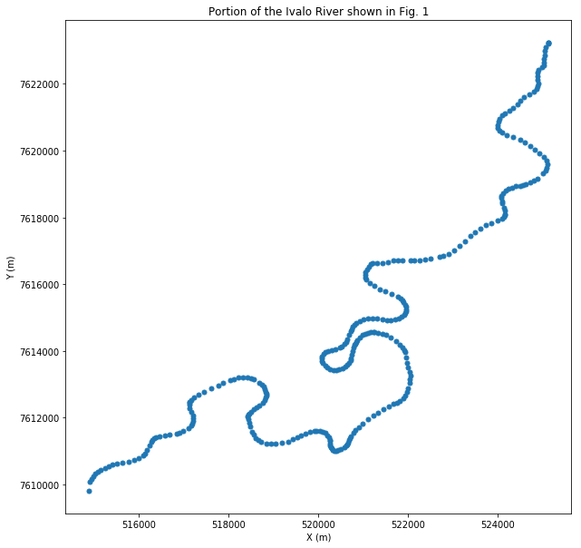

```python
plt.figure(figsize = (10,10))
plt.plot(centerline.x,centerline.y,'.',markersize = 10)

plt.xlabel('X (m)')
plt.ylabel('Y (m)')
plt.title('Portion of the Ivalo River shown in Fig. 1')
plt.show()
```

**Figure 2.** Plot showing nodes of the digitized channel centerline.

## How does the along-channel elevation change?

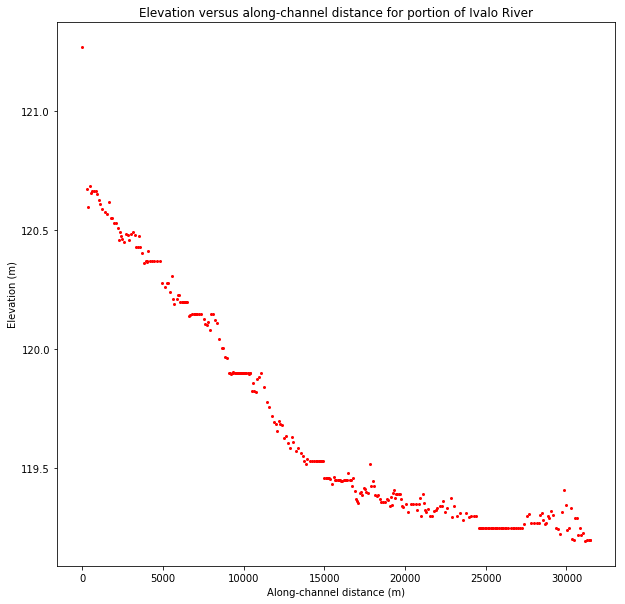

```python
plt.figure(figsize = (10,10))
plt.plot(centerline.river_dist,centerline.z,'.r',markersize = 4)
plt.xlabel('Along-channel distance (m)')
plt.ylabel('Elevation (m)')
plt.title('Elevation versus along-channel distance for portion of Ivalo River')
plt.show()
```

**Figure 3.** Plot showing elevation versus along-channel distance for a portion of the Ivalo River. We see that water surface elevation decreases downstream, as expected.

## Compute the curvature of the channel centerline using a function created called curvature()

One parameter of interest is the channel curvature, which has been shown to be, in some way, related to the migration rate of rivers (e.g., Sylvester et al., 2019). It is computed as follows (function adopted from workflow developed by Z. Sylvester).

```python
def curvature(x,y):
    """function computes curvature of curve defined in x and y space.
    The curvature is returned in units of 1/(unit of x and y).
    The distance along curve, s, is also computed and returned"""
    dx = np.gradient(x); dy = np.gradient(y)  # first derivatives
    ds = np.sqrt(dx**2+dy**2) #compute arc length
    ddx = np.gradient(dx); ddy = np.gradient(dy) # second derivatives
    curvature = (dx*ddy - dy*ddx) / ((dx**2 + dy**2)**1.5) # curvature
    s = np.cumsum(ds) # along-channel distance
    return curvature, s
```

```python
(channel_curvature,s) = curvature(centerline.x,centerline.y);
```

## Now examine the curvature of the channel centerline in X-Y space

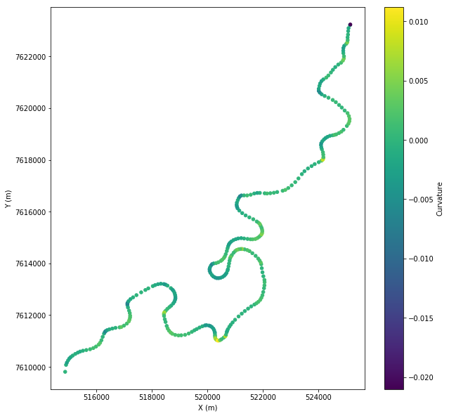

```python
plt.figure(figsize=(10,10))
plt.scatter(centerline.x,centerline.y,c=channel_curvature,s=20)

cbar = plt.colorbar()
cbar.set_label('Curvature')
plt.xlabel('X (m)')
plt.ylabel('Y (m)')
plt.show()
```

**Figure 4.** Plot showing the digitized centerline in x,y space, colored by the local curvature at each node.

## Plot the curvature versus along-channel distance to see how curvature changes along the channel centerline

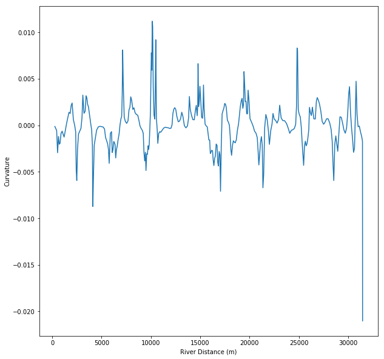

```python
plt.figure(figsize=(10,10))
plt.plot(s,channel_curvature);
plt.xlabel('River Distance (m)')
plt.ylabel('Curvature')
plt.show()
```

**Figure 5.** Plot showing the local curvature versus along-channel distance. Note that curvature oscillates between positive and negative values.

## Now compute the curvature of one of the digitized scroll bars and plot the scroll bar in planview as well as the curvature versus distance along the bar

```python
(bp1['curvature'],bp1['s'])=curvature(bp1.x,bp1.y)
bp1.head()
```

|  | x | y | z | curvature | s |
| --- | --- | --- | --- | --- | --- |
| 0 | 521957.0589 | 7612999.254 | 124.726997 | 0.000017 | 2.064146 |
| 1 | 521956.9648 | 7613001.316 | 124.837997 | 0.000014 | 4.127795 |
| 2 | 521956.8706 | 7613003.377 | 124.863998 | 0.000006 | 6.191446 |
| 3 | 521956.7764 | 7613005.439 | 124.889999 | -0.000006 | 8.255097 |
| 4 | 521956.6822 | 7613007.500 | 124.917000 | -0.000006 | 10.318746 |

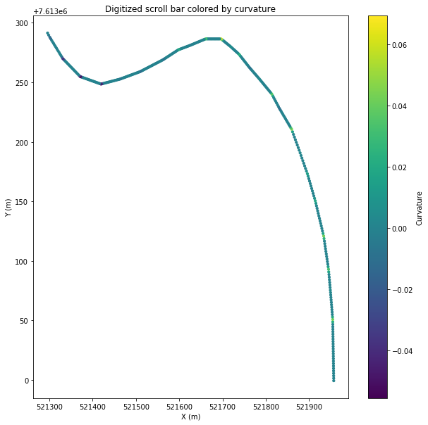

```python
plt.figure(figsize=(10,10))
plt.scatter(bp1.x,bp1.y,c=bp1.curvature,s=10)
cbar = plt.colorbar()
cbar.set_label('Curvature')
plt.xlabel('X (m)')
plt.ylabel('Y (m)')
plt.title('Digitized scroll bar colored by curvature')
plt.show()
```

**Figure 6.** Plot showing one of the digitized scroll bars in x,y space, colored by local curvature.

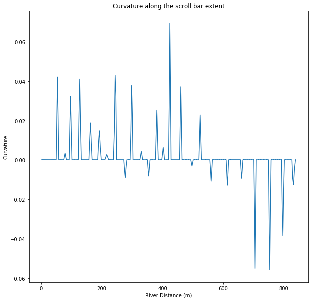

```python
plt.figure(figsize=(10,10))
plt.plot(bp1.s,bp1.curvature)
plt.xlabel('River Distance (m)')
plt.ylabel('Curvature')
plt.title('Curvature along the scroll bar extent')
plt.show()
```

**Figure 7.** Plot of local bar curvature versus distance along the bar. Again note the oscillation between negative and positive curvature values.

## Plot the elevation along the scroll versus the distance

One of the things that I was interested in exploring is the relationship between channel curvature and bar elevation. Below we plot the channel scroll bar elevation versus the along channel distance. We see that there is a significant decrease in elevation. Where does this occur with respect to the inflection point (i.e. point where curvature = 0 and curvature changes from positive to negative values)?

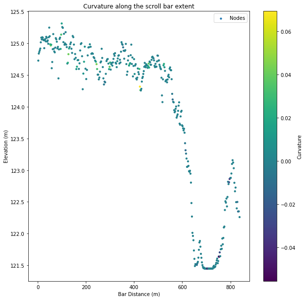

```python
plt.figure(figsize=(10,10))
plt.scatter(bp1.s,bp1.z,c=bp1.curvature,s=10,label='Nodes')
cbar = plt.colorbar()
cbar.set_label('Curvature')
plt.xlabel('Bar Distance (m)')
plt.ylabel('Elevation (m)')
plt.title('Curvature along the scroll bar extent')
plt.legend(loc='best')
plt.show()
```

## Identify inflection points along the bar

After plot of elevation versus distance, we compute the locations of the inflection points using a loop to identify where the curvature value is equal to zero.

```python
'''determine the locations of inflection points'''
inf = []
inf_s = []

for i,val in enumerate(bp1.curvature):
    if val == 0:
        inf.append(bp1.z[i])
        inf_s.append(bp1.s[i])

print(inf)
print(inf_s)
```

```
[124.4469986, 124.6900024, 124.6790009, 124.2559967, 124.28199769999999, 124.3960037, 124.45200349999999, 124.47200009999999, 124.5169983, 124.560997, 124.6289978, 124.6910019, 124.6439972, 124.62200159999998, 124.66999820000001, 124.65499879999999, 124.64900209999999, 124.612999, 124.0690002, 122.0…
[85.69621050348631, 307.38307674563396, 325.5214303045728, 428.13615592683124, 430.14180592683766, 432.14750592684646, 434.1531559268529, 436.1588059268593, 438.164505926839, 440.1702059268478, 442.17585592685424, 444.18150592686067, 446.18720592686947, 448.19290592684916, 450.1985559268556, 452.204…
```

Note that the number of inflection points computed above is far too many for one meander bend deposit. In fact we expect only 1 inflection point for each scroll bar profile. The result above is a product of user error when digitizing the profile, creating many false inflection points. We will need to smooth the curve. Shown in Fig. 9 is the elevation profile along the bar with the computed inflection points plotted.

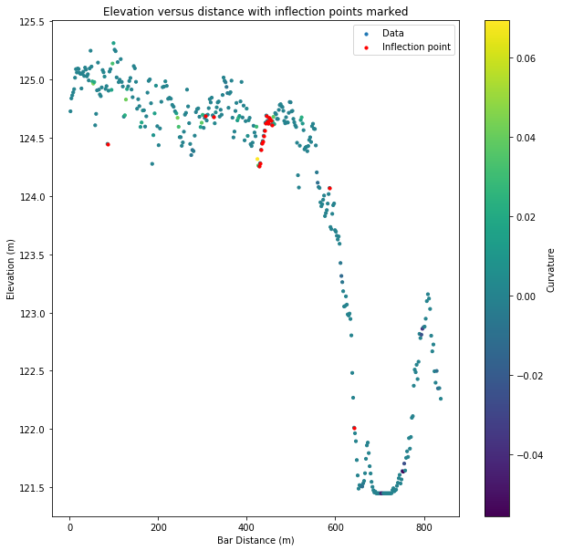

```python
plt.figure(figsize=(10,10))

plt.scatter(bp1.s,bp1.z,c=bp1.curvature,s=10,label='Data')
#want to plot inflection points now
cbar = plt.colorbar()
cbar.set_label('Curvature')
plt.xlabel('Bar Distance (m)')
plt.ylabel('Elevation (m)')
plt.scatter(inf_s,inf,c='r',s=10,label='Inflection point')
plt.legend(loc='best')
plt.title('Elevation versus distance with inflection points marked')
plt.show()
```

**Figure 9.** Plot of elevation versus distance along the point bar, colored by local bar curvature. Now the plot is shown with the locations of the computed inflection points. There should only be one inflection point; the others are artifacts.

## Smooth the channel centerline to remove false inflection points

Because the channel centerline should only have two inflection points per bend, I used a Savitzky-Golay (SG) to smooth the digitized lines to eliminate the user-error induced inflection point artifacts. The SG filter is a digital filter that subsets the data based on user input and fits low ordered polynomials to theses subsets. This results in an overall smoother curve. I used visual inspection to determine if the degree of smoothing was adaquate. This could be automated if I gave it a threshold value for curvature.

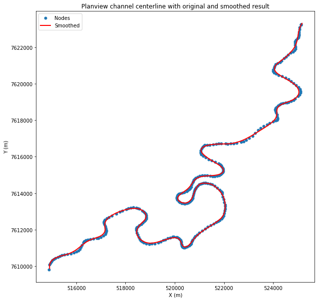

```python
#add columns to dataframe for the smoothed curve and plot
centerline['savgol_xnew'] = sp.signal.savgol_filter(centerline.x, 21,3)
centerline['savgol_ynew'] = sp.signal.savgol_filter(centerline.y, 21,3)

plt.figure(figsize=(10,10))

plt.plot(centerline.x,centerline.y,'.',markersize=10,label='Nodes')
plt.plot(centerline.savgol_xnew,centerline.savgol_ynew,'-r',linewidth=2,label='Smoothed')
plt.xlabel('X (m)')
plt.ylabel('Y (m)')
plt.title('Planview channel centerline with original and smoothed result')
plt.legend(loc="best")
plt.show()
```

**Figure 10.** Plot showing nodes of the digitized channel centerline and the Savitzky-Golay (SG) smoothed result.

## Repeat the smoothing procedure for the digitized scroll bar profiles

Because the scroll bar elevation and only expected to have one inflection point, we must follow the same procedure using the SG filter to smooth the profiles. Below we compute and plot an example of a smoothed scroll bar curve.

```python
#smooth and recompute curvature for the smoothed scroll bar profile (created from savgol filter)
bp1['savgol_xnew'] = sp.signal.savgol_filter(bp1.x, 101,3)
bp1['savgol_ynew'] = sp.signal.savgol_filter(bp1.y, 101,3)
bp1.head()
```

|  | x | y | z | curvature | s | savgol_xnew | savgol_ynew |
| --- | --- | --- | --- | --- | --- | --- | --- |
| 0 | 521957.0589 | 7612999.254 | 124.726997 | 0.000017 | 2.064146 | 521956.012762 | 7.612999e+06 |
| 1 | 521956.9648 | 7613001.316 | 124.837997 | 0.000014 | 4.127795 | 521956.124336 | 7.613001e+06 |
| 2 | 521956.8706 | 7613003.377 | 124.863998 | 0.000006 | 6.191446 | 521956.223052 | 7.613003e+06 |
| 3 | 521956.7764 | 7613005.439 | 124.889999 | -0.000006 | 8.255097 | 521956.308631 | 7.613005e+06 |
| 4 | 521956.6822 | 7613007.500 | 124.917000 | -0.000006 | 10.318746 | 521956.380794 | 7.613007e+06 |

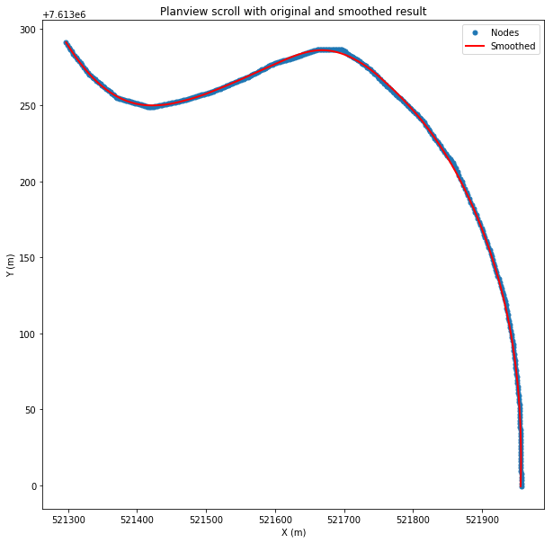

```python
plt.figure(figsize=(10,10))

plt.plot(bp1.x,bp1.y,'.',markersize=10,label='Nodes')
plt.plot(bp1.savgol_xnew,bp1.savgol_ynew,'-r',linewidth=2,label='Smoothed')
plt.legend(loc="best")
plt.xlabel('X (m)')
plt.ylabel('Y (m)')
plt.title('Planview scroll with original and smoothed result')
plt.show()
```

**Figure 11.** Plot showing nodes of the digitized scroll bar and the Savitzky-Golay (SG) smoothed result.

## Compute new curvature for channel centerline and plot the smoothed and unsmoothed result

Now that the digitized channel centerline has been smoothed we can compute the new curvature using the smoothed centerline Interestingly, it appears the smoothing processes results in a phase shift between the two centerlines when plotted in curvature-river distance space (see Fig. 12). This is an issue additional work to resolve. It isn't crucial for the subsequent analysis.

Importantly, note that the smoothed curve does not oscillate between +/- curvature values as much (i.e., fewer inflection points; Fig. 12).

```python
((centerline['curvature_savgol'],centerline['s_savgol'])) = curvature(centerline.savgol_xnew,centerline.savgol_ynew);
(bp1['curvature_savgol'],bp1['s_savgol'])=curvature(bp1.savgol_xnew,bp1.savgol_ynew)
bp1.head()
```

|  | x | y | z | curvature | s | savgol_xnew | savgol_ynew | curvature_savgol | s_savgol |
| --- | --- | --- | --- | --- | --- | --- | --- | --- | --- |
| 0 | 521957.0589 | 7612999.254 | 124.726997 | 0.000017 | 2.064146 | 521956.012762 | 7.612999e+06 | 0.001580 | 2.028225 |
| 1 | 521956.9648 | 7613001.316 | 124.837997 | 0.000014 | 4.127795 | 521956.124336 | 7.613001e+06 | 0.002383 | 4.057573 |
| 2 | 521956.8706 | 7613003.377 | 124.863998 | 0.000006 | 6.191446 | 521956.223052 | 7.613003e+06 | 0.003211 | 6.089200 |
| 3 | 521956.7764 | 7613005.439 | 124.889999 | -0.000006 | 8.255097 | 521956.308631 | 7.613005e+06 | 0.003267 | 8.123143 |
| 4 | 521956.6822 | 7613007.500 | 124.917000 | -0.000006 | 10.318746 | 521956.380794 | 7.613007e+06 | 0.003323 | 10.159440 |

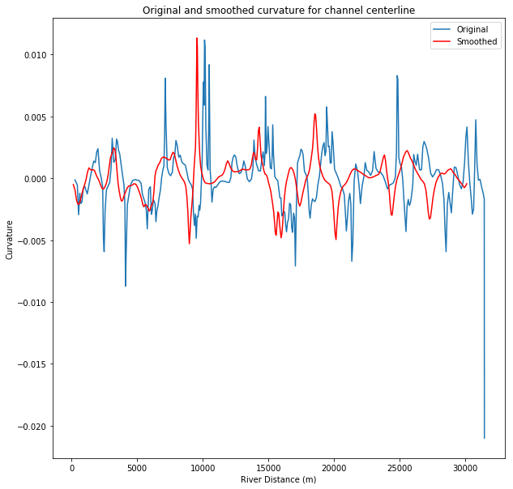

```python
plt.figure(figsize=(10,10))
plt.plot(s,channel_curvature,label="Original");
plt.plot(centerline.s_savgol,centerline.curvature_savgol,'-r',label="Smoothed");
plt.xlabel('River Distance (m)')
plt.ylabel('Curvature')
plt.legend(loc="best")
plt.title('Original and smoothed curvature for channel centerline')
plt.show()
```

**Figure 12.** Plot showing channel centerline curvature along the distance of the river for the unsmoothed and smoothed case. Note the phase shift between the curves which results from the smoothing process. Note now that the oscillation between +/- curvature values are far fewer for the smoothed curve (i.e., fewer inflection points).

## Compute and plot the curvature for a smoothed and unsmoothed scroll bar profile and plot the two in the the same space to compare

Same procedure as with the channel centerline except using one of the digitized scroll bar profiles.

```python
#smooth and recompute curvature for the smoothed scroll bar profile (created from savgol filter)
bp1['savgol_xnew'] = sp.signal.savgol_filter(bp1.x, 151,3)
bp1['savgol_ynew'] = sp.signal.savgol_filter(bp1.y, 151,3)

(bp1['curvature_savgol'],bp1['s_savgol'])=curvature(bp1.savgol_xnew,bp1.savgol_ynew)
bp1.head()
```

|  | x | y | z | curvature | s | savgol_xnew | savgol_ynew | curvature_savgol | s_savgol |
| --- | --- | --- | --- | --- | --- | --- | --- | --- | --- |
| 0 | 521957.0589 | 7612999.254 | 124.726997 | 0.000017 | 2.064146 | 521951.260805 | 7.613001e+06 | 0.006527 | 1.880301 |
| 1 | 521956.9648 | 7613001.316 | 124.837997 | 0.000014 | 4.127795 | 521951.958472 | 7.613003e+06 | 0.009749 | 3.761408 |
| 2 | 521956.8706 | 7613003.377 | 124.863998 | 0.000006 | 6.191446 | 521952.613770 | 7.613005e+06 | 0.012871 | 5.644850 |
| 3 | 521956.7764 | 7613005.439 | 124.889999 | -0.000006 | 8.255097 | 521953.227011 | 7.613007e+06 | 0.012689 | 7.531488 |
| 4 | 521956.6822 | 7613007.500 | 124.917000 | -0.000006 | 10.318746 | 521953.798507 | 7.613009e+06 | 0.012494 | 9.422146 |

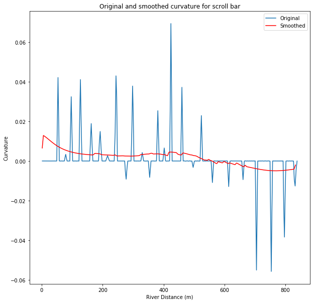

```python
plt.figure(figsize=(10,10))
plt.plot(bp1.s,bp1.curvature,label="Original");
plt.plot(bp1.s_savgol,bp1.curvature_savgol,'-r',label="Smoothed");
plt.xlabel('River Distance (m)')
plt.ylabel('Curvature')
plt.legend(loc="best")
plt.title('Original and smoothed curvature for scroll bar')
plt.show()
```

**Figure 13.** Plot showing scroll bar curvature along the distance of the river for the unsmoothed and smoothed case. Note the phase shift between the curves which results from the smoothing process. Note now that the oscillation between +/- curvature values are far fewer for the smoothed curve (i.e., fewer inflection points).

## Compute new inflection points and plot elevation versus distance for smoothed profile with inflection points highlighted

Now we compute and plot the inflection point for the smoothed curve to determine it's position on the scroll bar with respect to changes in bar elevation.

```python
#find inflection points
inf_savgol = []
inf_s_savgol = []

#the steps below were how I chose to identify inflection points, by a change of sign.
last_sign = 1

for i,val in enumerate(bp1.curvature_savgol):
    if val == 0:
        sign = -1

    else:
        sign = val/abs(val)

    if sign != last_sign:
        inf_savgol.append(bp1.z[i])
        inf_s_savgol.append(bp1.s_savgol[i])
        break


print('There are',len(inf_savgol),'inflection points')
```

```
There are 1 inflection points
```

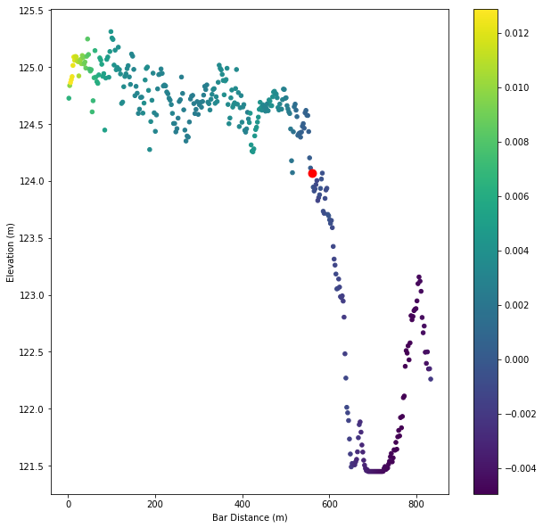

```python
#scatter colored by curvature values of interpolated curve using savgol filter
plt.figure(figsize=(10,10))

plt.scatter(bp1.s_savgol,bp1.z,c=bp1.curvature_savgol,s=20,label='Smoothed Nodes')
cbar.set_label('Curvature')
cbar = plt.colorbar()
plt.scatter(inf_s_savgol,inf_savgol,c='r',s=80,label='Inflection Points')
plt.xlabel('Bar Distance (m)')
plt.ylabel('Elevation (m)')
plt.show()
```

**Figure 14.** Plot showing scroll bar elevation versus distance along the bar, colored by curvature. The inflection point is marked in red. Note that the inflection point occurs very near the change from high to low elevation.

## To perform this analysis for all 17 scroll bars, I wrote a function compute_bar_params()

The function below takes the digitized curve, the window length, and the order polynomial to use for the Savitzky-Golay filter as arguments. It performs the same steps as shown above in detail. Importantly, every parameter that is calculated is returned in a dataframe at the end of the function which promotes further statistical analysis in subsequent steps.

```python
def compute_bar_params(bar_profile,sw,order):

    #apply smoothing using the Savitzky-Golay filter method
    bar_profile['savgol_xnew'] = sp.signal.savgol_filter(bar_profile.x, sw,order)
    bar_profile['savgol_ynew'] = sp.signal.savgol_filter(bar_profile.y, sw,order)

    #compute curvature for the smoothed profile (created from savgol filter)
    (bar_profile['curvature_savgol'],bar_profile['s_savgol'])=curvature(bar_profile.savgol_xnew,bar_profile.savgol_ynew)


    #convert the column of the pandas dataframe to a numpy array for the next steps
    bar_profile_curvature_savgol_np = np.matrix(bar_profile.curvature_savgol)
    bar_profile_curvature_savgol_np = bar_profile_curvature_savgol_np.transpose()

    #inflection values of interpolated curve using savgol filter
    inf_savgol = []
    inf_s_savgol = []
    inf_x = 0
    inf_y = 0

    if bar_profile_curvature_savgol_np[0,0] < 0:
        bar_profile_curvature_savgol_np= bar_profile_curvature_savgol_np[::-1]


    #the steps below were how I chose to identify inflection points, by a change of sign.
    last_sign = 1

    for i,val in enumerate(bar_profile_curvature_savgol_np):
        if val == 0:
            sign = -1

        else:
            sign = val/abs(val)

        if sign != last_sign:
            inf_savgol.append(bar_profile.z[i])
            inf_s_savgol.append(bar_profile.s_savgol[i])
            inf_x = bar_profile.x[i]
            inf_y = bar_profile.y[i]
            break


    #plotting with subplots
    fig=plt.figure(figsize=(20,10))

    ax2=fig.add_subplot(1,2,1)
    ax2.set_ylim([bar_profile.y.min(), bar_profile.y.max()])
    ax2.plot(bar_profile.x,bar_profile.y,'o',markersize=10,fillstyle='none',label='Digitized Bar Profile Nodes')
    ax2.plot(bar_profile.savgol_xnew,bar_profile.savgol_ynew,'-r',Linewidth='4',label='Smoothed Centerline')
    ax2.plot(inf_x,inf_y,'or',markersize=15,label='Inflection Point')
    ax2.ticklabel_format(style='plain', axis='both', scilimits=None)

    ax2.set_xlabel('X(m)')
    ax2.set_ylabel('Y(m)')

    plt.legend(loc='best')
    plt.ticklabel_format(style='plain', axis='both', scilimits=None)
    ax2.ticklabel_format(axis='both', style='plain', scilimits=None, useOffset=None, useLocale=None, useMathText=None)


    ax4=fig.add_subplot(1,2,2)
    im = ax4.scatter(bar_profile.s_savgol,bar_profile.z,c=bar_profile.curvature_savgol,s=10,cmap = plt.cm.viridis,label=None)
    fig.colorbar(im,ax=ax4)


    ax4.scatter(inf_s_savgol,inf_savgol,c='r',s=120,label='Inflection Point')
    ax4.set_xlabel('Distance along Bar (m)')
    ax4.set_ylabel('Elevation (m)')
    plt.legend(loc='best')


    print('Number of inflection points:',len(inf_savgol))

    return bar_profile
```

## In the next 17 cells this function is run for each scroll bar across the two meander bends

The above function is now run with different SG inputs for window length and polynomial order. I display the first 5 rows for each curve and plot the planview bar profile and the elevation of the bar versus distance with the inflection points notes. Qualitatively, there is an interesting relationship between the location of the inflection point and the stream-wise change in elevation along the bar.

```
Number of inflection points: 1
```

|  | x | y | z | curvature | s | savgol_xnew | savgol_ynew | curvature_savgol | s_savgol |
| --- | --- | --- | --- | --- | --- | --- | --- | --- | --- |
| 0 | 521957.0589 | 7612999.254 | 124.726997 | 0.000017 | 2.064146 | 521951.382651 | 7.613002e+06 | 0.006606 | 1.863552 |
| 1 | 521956.9648 | 7613001.316 | 124.837997 | 0.000014 | 4.127795 | 521952.068009 | 7.613003e+06 | 0.009859 | 3.728331 |
| 2 | 521956.8706 | 7613003.377 | 124.863998 | 0.000006 | 6.191446 | 521952.711500 | 7.613005e+06 | 0.012999 | 5.596277 |
| 3 | 521956.7764 | 7613005.439 | 124.889999 | -0.000006 | 8.255097 | 521953.313425 | 7.613007e+06 | 0.012799 | 7.468235 |
| 4 | 521956.6822 | 7613007.500 | 124.917000 | -0.000006 | 10.318746 | 521953.874090 | 7.613009e+06 | 0.012586 | 9.345010 |

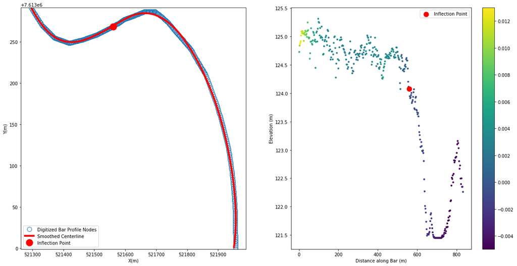

```python
compute_bar_params(bp1,149,3)
bp1.head()
```

```
Number of inflection points: 1
```

|  | x | y | z | savgol_xnew | savgol_ynew | curvature_savgol | s_savgol |
| --- | --- | --- | --- | --- | --- | --- | --- |
| 0 | 521960.8568 | 7613183.930 | 123.837997 | 521960.772021 | 7.613178e+06 | 0.001935 | 2.416078 |
| 1 | 521960.4882 | 7613185.994 | 123.683998 | 521960.688649 | 7.613180e+06 | 0.002906 | 4.829564 |
| 2 | 521960.1196 | 7613188.058 | 123.674004 | 521960.582885 | 7.613182e+06 | 0.003885 | 7.238006 |
| 3 | 521959.7510 | 7613190.123 | 123.910004 | 521960.454850 | 7.613185e+06 | 0.003888 | 9.641574 |
| 4 | 521959.3823 | 7613192.187 | 123.848999 | 521960.304667 | 7.613187e+06 | 0.003890 | 12.040436 |

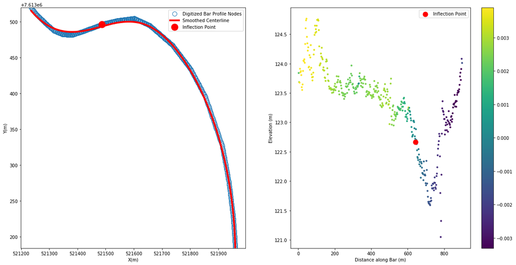

```python
compute_bar_params(bp2,281,3)
bp2.head()
```

```
Number of inflection points: 1
```

|  | x | y | z | savgol_xnew | savgol_ynew | curvature_savgol | s_savgol |
| --- | --- | --- | --- | --- | --- | --- | --- |
| 0 | 521977.8401 | 7613123.792 | 124.652000 | 521973.918696 | 7.613129e+06 | 0.003273 | 1.678925 |
| 1 | 521977.7967 | 7613125.845 | 124.764000 | 521974.296776 | 7.613130e+06 | 0.004860 | 3.362822 |
| 2 | 521977.7533 | 7613127.899 | 124.825996 | 521974.659107 | 7.613132e+06 | 0.006353 | 5.056726 |
| 3 | 521977.7099 | 7613129.953 | 124.817001 | 521975.005711 | 7.613134e+06 | 0.006222 | 6.760660 |
| 4 | 521977.6665 | 7613132.007 | 124.861000 | 521975.336607 | 7.613135e+06 | 0.006094 | 8.474641 |

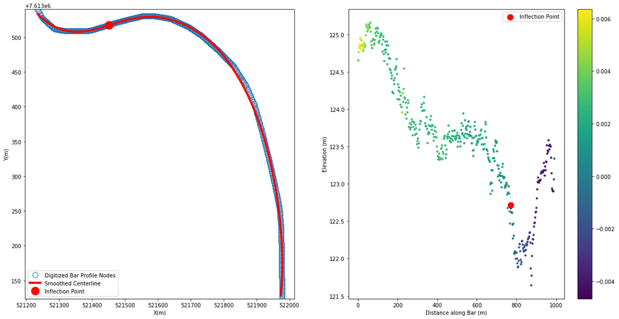

```python
compute_bar_params(bp3,211,3)
bp3.head()
```

```
Number of inflection points: 1
```

|  | x | y | z | savgol_xnew | savgol_ynew | curvature_savgol | s_savgol |
| --- | --- | --- | --- | --- | --- | --- | --- |
| 0 | 521960.8316 | 7613304.405 | 124.309998 | 521956.269695 | 7.613302e+06 | 0.002503 | 2.180231 |
| 1 | 521960.1953 | 7613306.449 | 124.513000 | 521956.126207 | 7.613304e+06 | 0.003741 | 4.361733 |
| 2 | 521959.5589 | 7613308.493 | 124.468002 | 521955.958810 | 7.613306e+06 | 0.004951 | 6.545907 |
| 3 | 521958.9225 | 7613310.538 | 124.638000 | 521955.767651 | 7.613308e+06 | 0.004903 | 8.732879 |
| 4 | 521958.2862 | 7613312.582 | 124.532997 | 521955.552876 | 7.613310e+06 | 0.004856 | 10.922768 |

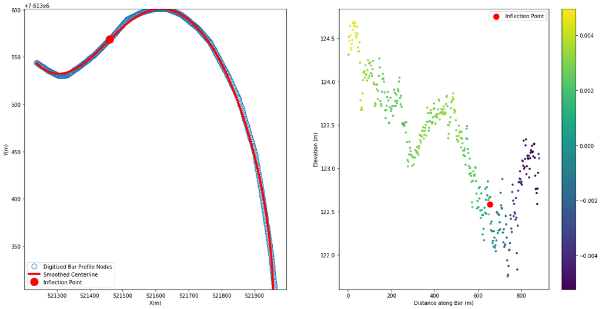

```python
compute_bar_params(bp4,217,3)
bp4.head()
```

```
Number of inflection points: 1
```

|  | x | y | z | savgol_xnew | savgol_ynew | curvature_savgol | s_savgol |
| --- | --- | --- | --- | --- | --- | --- | --- |
| 0 | 521965.2862 | 7613346.926 | 124.491997 | 521961.387473 | 7.613345e+06 | 0.003009 | 2.121471 |
| 1 | 521964.8285 | 7613348.969 | 124.556000 | 521961.409731 | 7.613347e+06 | 0.004500 | 4.243531 |
| 2 | 521964.3707 | 7613351.011 | 124.581001 | 521961.404915 | 7.613349e+06 | 0.005963 | 6.366974 |
| 3 | 521963.9129 | 7613353.054 | 124.540001 | 521961.373199 | 7.613351e+06 | 0.005912 | 8.492025 |
| 4 | 521963.4551 | 7613355.096 | 124.556000 | 521961.314754 | 7.613353e+06 | 0.005860 | 10.618903 |

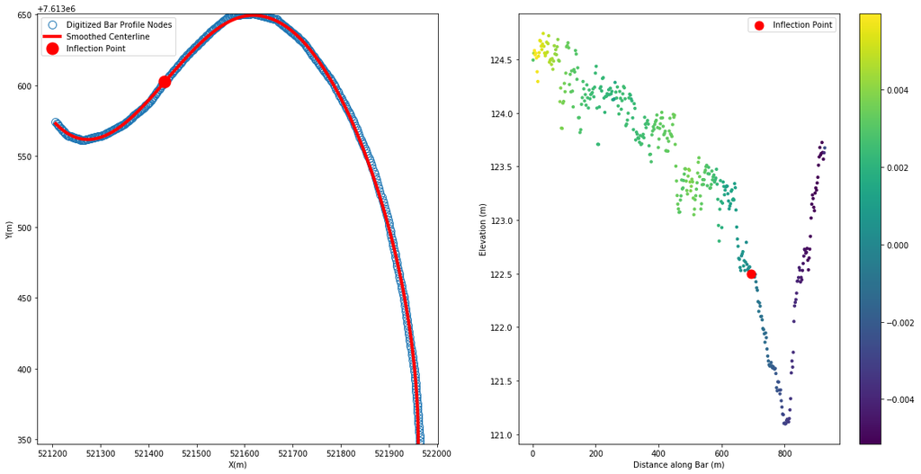

```python
compute_bar_params(bp5,221,3)
bp5.head()
```

```
Number of inflection points: 1
```

|  | x | y | z | savgol_xnew | savgol_ynew | curvature_savgol | s_savgol |
| --- | --- | --- | --- | --- | --- | --- | --- |
| 0 | 521945.8480 | 7613480.969 | 124.668999 | 521944.034418 | 7.613477e+06 | 0.002016 | 2.387166 |
| 1 | 521944.9135 | 7613483.009 | 124.442001 | 521943.462873 | 7.613479e+06 | 0.003016 | 4.774849 |
| 2 | 521943.9790 | 7613485.050 | 124.614998 | 521942.868784 | 7.613482e+06 | 0.004000 | 7.163669 |
| 3 | 521943.0444 | 7613487.090 | 124.610001 | 521942.252317 | 7.613484e+06 | 0.003970 | 9.553711 |
| 4 | 521942.1099 | 7613489.131 | 124.542999 | 521941.613633 | 7.613486e+06 | 0.003940 | 11.945061 |

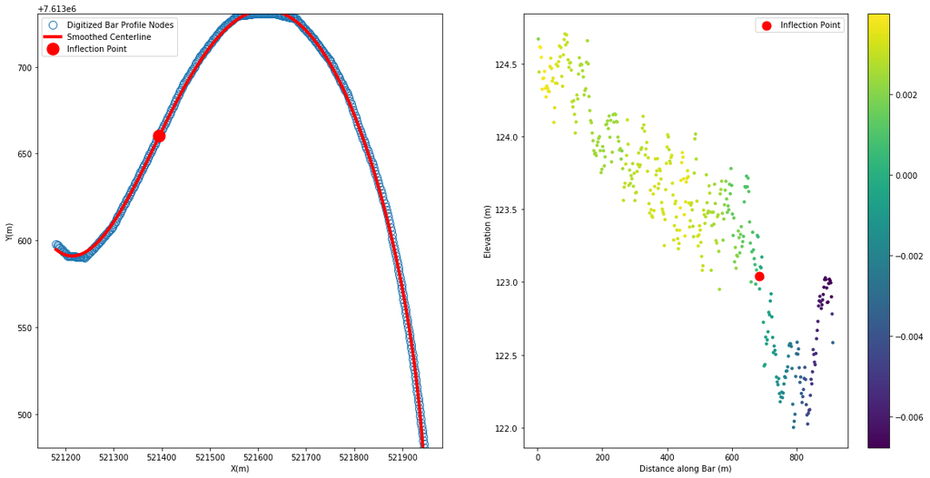

```python
compute_bar_params(bp6,211,3)
bp6.head()
```

```
Number of inflection points: 1
```

|  | x | y | z | savgol_xnew | savgol_ynew | curvature_savgol | s_savgol |
| --- | --- | --- | --- | --- | --- | --- | --- |
| 0 | 521841.9750 | 7613719.087 | 124.044998 | 521841.666855 | 7.613718e+06 | 0.000642 | 2.358143 |
| 1 | 521839.9264 | 7613720.112 | 123.959000 | 521839.634767 | 7.613719e+06 | 0.000967 | 4.713851 |
| 2 | 521837.8778 | 7613721.136 | 124.041000 | 521837.603258 | 7.613720e+06 | 0.001299 | 7.064704 |
| 3 | 521835.8291 | 7613722.160 | 123.942001 | 521835.572320 | 7.613721e+06 | 0.001310 | 9.410724 |
| 4 | 521833.7805 | 7613723.185 | 124.041000 | 521833.541947 | 7.613723e+06 | 0.001321 | 11.751931 |

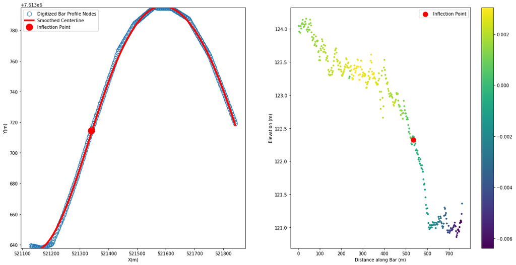

```python
compute_bar_params(bp7,221,3)
bp7.head()
```

```
Number of inflection points: 1
```

|  | x | y | z | savgol_xnew | savgol_ynew | curvature_savgol | s_savgol |
| --- | --- | --- | --- | --- | --- | --- | --- |
| 0 | 521836.3055 | 7613755.129 | 124.314003 | 521836.638576 | 7.613756e+06 | 0.000850 | 2.533601 |
| 1 | 521834.2807 | 7613756.573 | 124.413002 | 521834.595155 | 7.613757e+06 | 0.001280 | 5.063273 |
| 2 | 521832.2559 | 7613758.017 | 124.336998 | 521832.551632 | 7.613759e+06 | 0.001719 | 7.585129 |
| 3 | 521830.2311 | 7613759.460 | 124.223999 | 521830.508009 | 7.613760e+06 | 0.001731 | 10.099234 |
| 4 | 521828.2063 | 7613760.904 | 124.126000 | 521828.464288 | 7.613762e+06 | 0.001744 | 12.605649 |

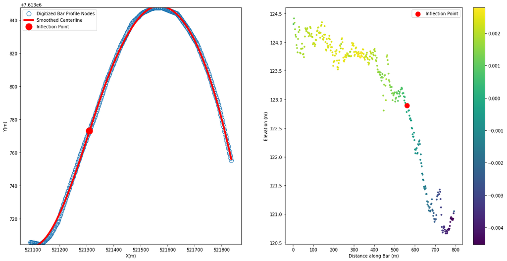

```python
compute_bar_params(bp8,211,3)
bp8.head()
```

```
Number of inflection points: 1
```

|  | x | y | z | savgol_xnew | savgol_ynew | curvature_savgol | s_savgol |
| --- | --- | --- | --- | --- | --- | --- | --- |
| 0 | 521831.4460 | 7613784.691 | 123.802002 | 521830.807945 | 7.613785e+06 | 0.001027 | 2.477872 |
| 1 | 521829.3706 | 7613786.083 | 123.906998 | 521828.798065 | 7.613786e+06 | 0.001546 | 4.951703 |
| 2 | 521827.2951 | 7613787.475 | 123.952003 | 521826.787378 | 7.613787e+06 | 0.002077 | 7.417510 |
| 3 | 521825.2197 | 7613788.867 | 123.931999 | 521824.775894 | 7.613789e+06 | 0.002089 | 9.875380 |
| 4 | 521823.1442 | 7613790.260 | 124.126000 | 521822.763620 | 7.613790e+06 | 0.002102 | 12.325402 |

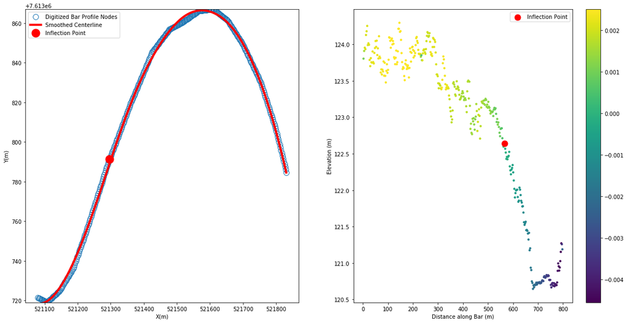

```python
compute_bar_params(bp9,211,3)
bp9.head()
```

```
Number of inflection points: 1
```

|  | x | y | z | savgol_xnew | savgol_ynew | curvature_savgol | s_savgol |
| --- | --- | --- | --- | --- | --- | --- | --- |
| 0 | 521760.5775 | 7613932.806 | 123.945999 | 521760.705735 | 7.613933e+06 | -0.000355 | 2.206399 |
| 1 | 521758.5527 | 7613933.684 | 124.014999 | 521758.664273 | 7.613934e+06 | -0.000525 | 4.413086 |
| 2 | 521756.5278 | 7613934.561 | 124.080002 | 521756.623594 | 7.613935e+06 | -0.000679 | 6.620327 |
| 3 | 521754.5030 | 7613935.439 | 123.987000 | 521754.583686 | 7.613936e+06 | -0.000647 | 8.828075 |
| 4 | 521752.4782 | 7613936.316 | 123.922997 | 521752.544539 | 7.613936e+06 | -0.000616 | 11.036284 |

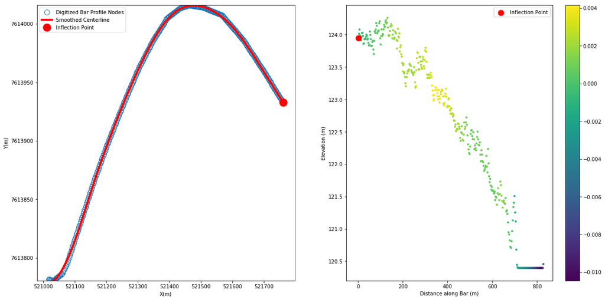

```python
compute_bar_params(bp10,111,3)
bp10.head()
```

```
Number of inflection points: 1
```

|  | x | y | z | savgol_xnew | savgol_ynew | curvature_savgol | s_savgol |
| --- | --- | --- | --- | --- | --- | --- | --- |
| 0 | 521736.0772 | 7614050.246 | 123.674004 | 521735.757216 | 7.614049e+06 | 0.000351 | 2.434877 |
| 1 | 521734.0048 | 7614051.461 | 123.740997 | 521733.707955 | 7.614051e+06 | 0.000529 | 4.868296 |
| 2 | 521731.9323 | 7614052.676 | 123.637001 | 521731.658901 | 7.614052e+06 | 0.000713 | 7.298793 |
| 3 | 521729.8598 | 7614053.890 | 123.575996 | 521729.610051 | 7.614053e+06 | 0.000721 | 9.726358 |
| 4 | 521727.7874 | 7614055.105 | 123.470001 | 521727.561402 | 7.614054e+06 | 0.000730 | 12.150977 |

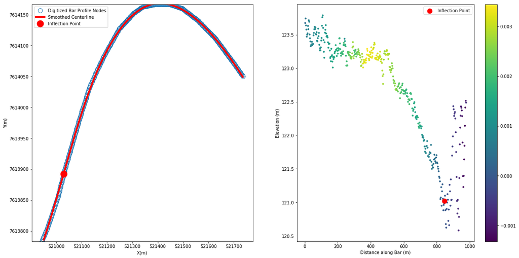

```python
compute_bar_params(bp11,211,3)
bp11.head()
```

```
Number of inflection points: 1
```

|  | x | y | z | savgol_xnew | savgol_ynew | curvature_savgol | s_savgol |
| --- | --- | --- | --- | --- | --- | --- | --- |
| 0 | 521712.5894 | 7614140.552 | 123.614998 | 521712.438732 | 7.614141e+06 | 0.000561 | 2.719886 |
| 1 | 521710.5645 | 7614142.302 | 123.637001 | 521710.428317 | 7.614143e+06 | 0.000844 | 5.436440 |
| 2 | 521708.5397 | 7614144.053 | 123.718002 | 521708.417243 | 7.614145e+06 | 0.001132 | 8.146351 |
| 3 | 521706.5149 | 7614145.803 | 123.832001 | 521706.405517 | 7.614146e+06 | 0.001138 | 10.849653 |
| 4 | 521704.4901 | 7614147.553 | 123.746002 | 521704.393143 | 7.614148e+06 | 0.001145 | 13.546375 |

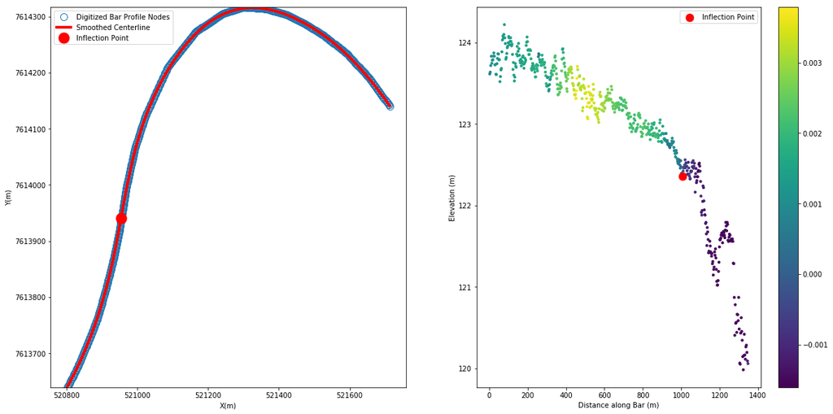

```python
compute_bar_params(bp12,211,3)
bp12.head()
```

```
Number of inflection points: 1
```

|  | x | y | z | savgol_xnew | savgol_ynew | curvature_savgol | s_savgol |
| --- | --- | --- | --- | --- | --- | --- | --- |
| 0 | 517200.4922 | 7612338.265 | 125.957001 | 517199.957547 | 7.612335e+06 | -0.000909 | 2.170092 |
| 1 | 517202.5071 | 7612338.719 | 125.851997 | 517202.003762 | 7.612336e+06 | -0.001366 | 4.338469 |
| 2 | 517204.5220 | 7612339.174 | 125.787003 | 517204.049586 | 7.612336e+06 | -0.001828 | 6.503447 |
| 3 | 517206.5370 | 7612339.628 | 125.776001 | 517206.095023 | 7.612337e+06 | -0.001835 | 8.665066 |
| 4 | 517208.5519 | 7612340.082 | 125.773003 | 517208.140078 | 7.612338e+06 | -0.001842 | 10.823366 |

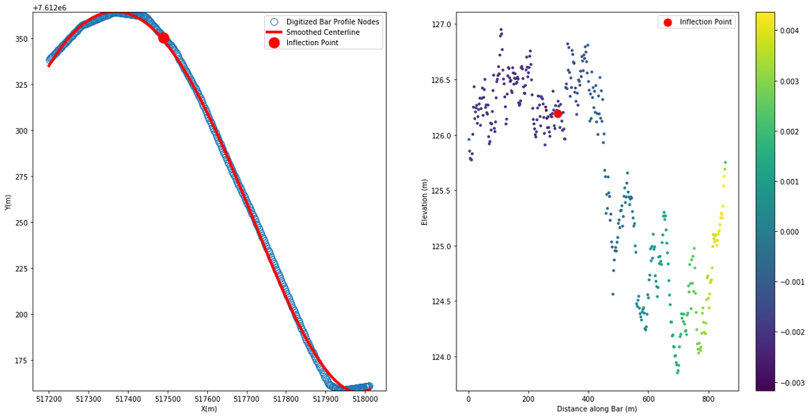

```python
compute_bar_params(bp13,251,3)
bp13.head()
```

```
Number of inflection points: 1
```

|  | x | y | z | savgol_xnew | savgol_ynew | curvature_savgol | s_savgol |
| --- | --- | --- | --- | --- | --- | --- | --- |
| 0 | 517194.8227 | 7612424.927 | 126.973999 | 517194.758312 | 7.612427e+06 | -0.000120 | 2.355447 |
| 1 | 517196.8250 | 7612426.277 | 126.998001 | 517196.763908 | 7.612428e+06 | -0.000182 | 4.710510 |
| 2 | 517198.8273 | 7612427.627 | 127.042000 | 517198.769549 | 7.612430e+06 | -0.000250 | 7.064791 |
| 3 | 517200.8296 | 7612428.977 | 127.181000 | 517200.775237 | 7.612431e+06 | -0.000261 | 9.418259 |
| 4 | 517202.8319 | 7612430.326 | 127.240997 | 517202.780975 | 7.612432e+06 | -0.000272 | 11.770885 |

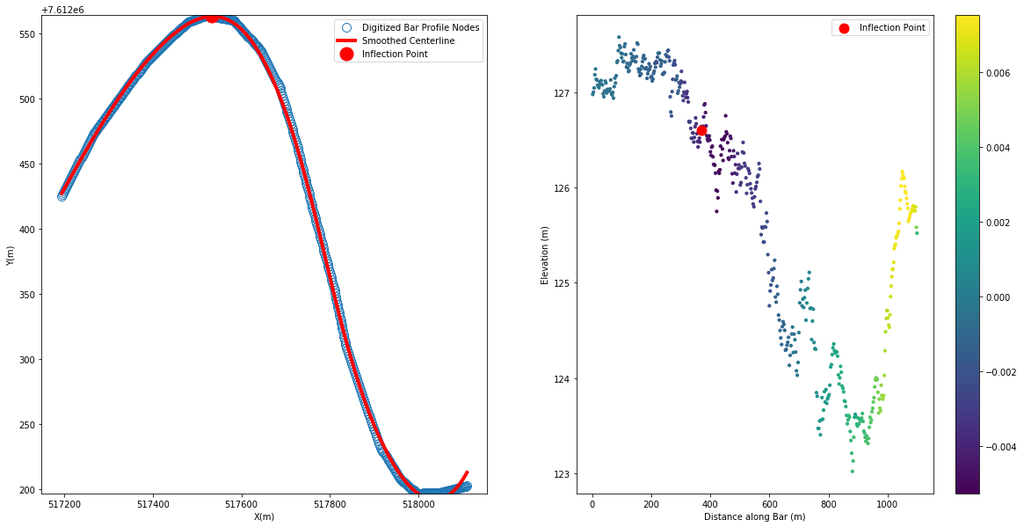

```python
compute_bar_params(bp14,191,3)
bp14.head()
```

```
Number of inflection points: 1
```

|  | x | y | z | savgol_xnew | savgol_ynew | curvature_savgol | s_savgol |
| --- | --- | --- | --- | --- | --- | --- | --- |
| 0 | 517646.7613 | 7612710.831 | 127.263000 | 517648.614103 | 7.612705e+06 | -0.003903 | 1.866553 |
| 1 | 517648.7977 | 7612710.646 | 127.239998 | 517650.427013 | 7.612705e+06 | -0.005820 | 3.735515 |
| 2 | 517650.8341 | 7612710.461 | 127.274002 | 517652.250980 | 7.612706e+06 | -0.007669 | 5.609506 |
| 3 | 517652.8705 | 7612710.275 | 127.314003 | 517654.085803 | 7.612706e+06 | -0.007562 | 7.488741 |
| 4 | 517654.9069 | 7612710.090 | 127.297997 | 517655.931282 | 7.612706e+06 | -0.007454 | 9.373426 |

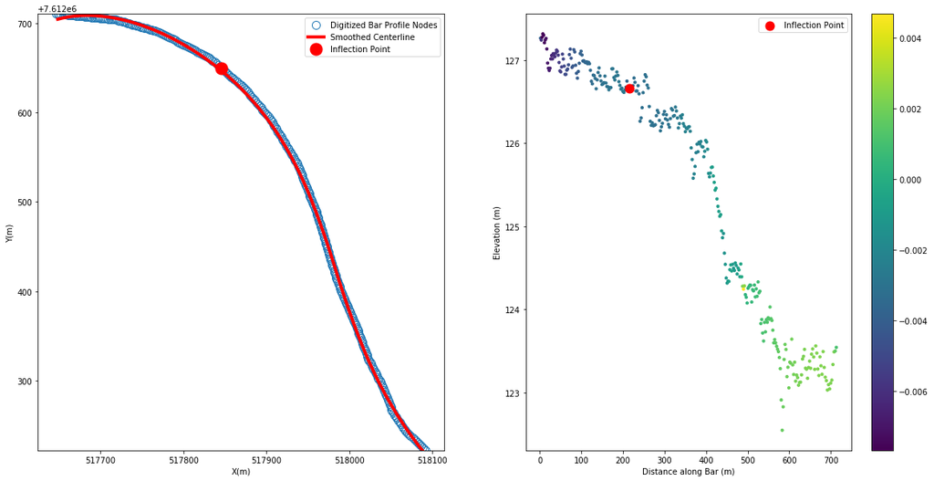

```python
compute_bar_params(bp15,191,3)
bp15.head()
```

```
Number of inflection points: 1
```

|  | x | y | z | savgol_xnew | savgol_ynew | curvature_savgol | s_savgol |
| --- | --- | --- | --- | --- | --- | --- | --- |
| 0 | 517956.1530 | 7612948.139 | 125.440002 | 517957.931603 | 7.612948e+06 | -0.000825 | 1.888926 |
| 1 | 517958.1877 | 7612947.428 | 125.710999 | 517959.735914 | 7.612947e+06 | -0.001229 | 3.785031 |
| 2 | 517960.2224 | 7612946.717 | 125.745003 | 517961.552193 | 7.612946e+06 | -0.001618 | 5.695391 |
| 3 | 517962.2571 | 7612946.006 | 125.698998 | 517963.380196 | 7.612946e+06 | -0.001606 | 7.619801 |
| 4 | 517964.2918 | 7612945.294 | 125.751000 | 517965.219683 | 7.612945e+06 | -0.001595 | 9.558051 |

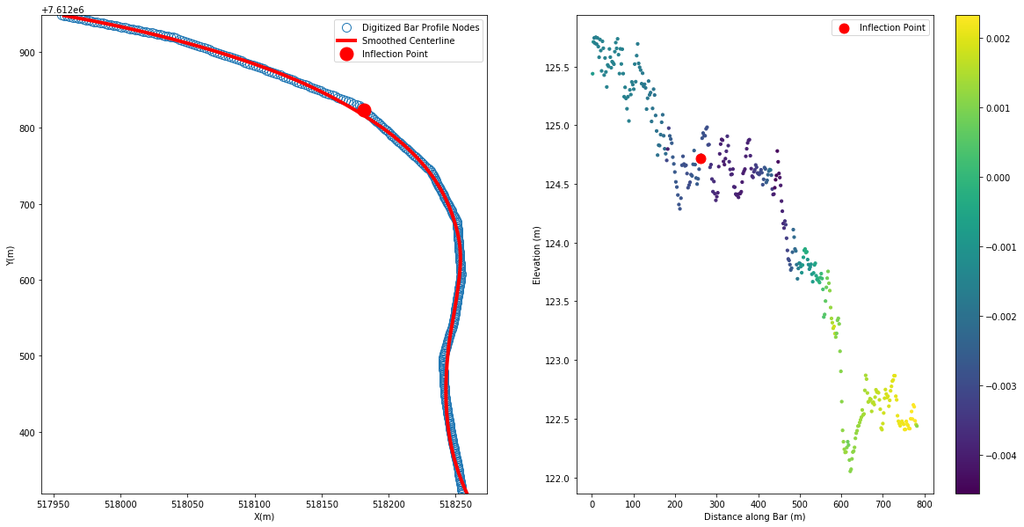

```python
compute_bar_params(bp16,161,3)
bp16.head()
```

```
Number of inflection points: 1
```

|  | x | y | z | savgol_xnew | savgol_ynew | curvature_savgol | s_savgol |
| --- | --- | --- | --- | --- | --- | --- | --- |
| 0 | 518050.9144 | 7613036.421 | 125.473999 | 518057.612457 | 7.613031e+06 | -0.002775 | 1.822870 |
| 1 | 518052.9179 | 7613036.933 | 125.622002 | 518059.160907 | 7.613032e+06 | -0.004146 | 3.647498 |
| 2 | 518054.9214 | 7613037.444 | 125.757004 | 518060.722036 | 7.613033e+06 | -0.005483 | 5.475725 |
| 3 | 518056.9249 | 7613037.956 | 125.808998 | 518062.295712 | 7.613034e+06 | -0.005432 | 7.307615 |
| 4 | 518058.9284 | 7613038.467 | 125.648003 | 518063.881801 | 7.613035e+06 | -0.005381 | 9.143234 |

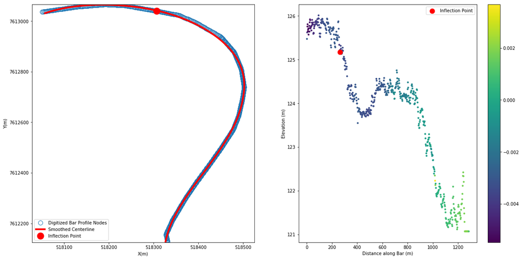

```python
compute_bar_params(bp17,251,3)
bp17.head()
```

## Let's look at some statistics for each meander bend

```python
#compute max and mean curvature and elevation for each profile
def curv_max_mean(bar_profile):
    max_curv = abs(bar_profile.curvature_savgol.max())
    mean_curv = abs(bar_profile.curvature_savgol.mean())

    max_elev = bar_profile.z.max()
    mean_elev = bar_profile.z.mean()

    bp = np.array([max_curv,mean_curv,max_elev,mean_elev])

    return bp
```

```python
#check the function using the first bar profile bp1
bp1_stats = curv_max_mean(bp1)
print(bp1_stats)

bp5_stats = curv_max_mean(bp5)
print(bp5_stats)
```

```
[1.29993650e-02 1.57149704e-03 1.25311997e+02 1.23929090e+02]
[5.96343581e-03 1.30383559e-03 1.24739998e+02 1.23377107e+02]
```

Now that we have tested the function for one of the scroll bars, we want to calculate these statistics for all of the curves and store them. We do this by first creating an array of pandas dataframes and then loop over this array and return an array with the statistics calculated.

```python
#make a numpy array of pandas dataframes. May not be the most computationally efficient thing to do, but it works
bp_array = np.array([bp1,bp2,bp3,bp4,bp5,bp6,bp7,bp8,bp9,bp10,bp11,bp12,bp13,bp14,bp15,bp16,bp17])
```

```python
#make new array that will contain bar profile statistics
bp_array2 = np.zeros([17,4])

for i,val in enumerate(bp_array):
     bp_array2[i] = curv_max_mean(bp_array[i])

np.transpose(bp_array2)

bp_stats = pd.DataFrame(bp_array2, columns=['maxCurvature','meanCurvature','maxElevation','meanElevation'])
bp_stats
```

|  | maxCurvature | meanCurvature | maxElevation | meanElevation |
| --- | --- | --- | --- | --- |
| 0 | 0.012999 | 0.001571 | 125.311997 | 123.929090 |
| 1 | 0.003892 | 0.001158 | 124.762001 | 123.294473 |
| 2 | 0.006353 | 0.001342 | 125.158997 | 123.613357 |
| 3 | 0.004951 | 0.001270 | 124.686997 | 123.296834 |
| 4 | 0.005963 | 0.001304 | 124.739998 | 123.377107 |
| 5 | 0.004000 | 0.001170 | 124.704002 | 123.479717 |
| 6 | 0.003034 | 0.000580 | 124.153999 | 122.731633 |
| 7 | 0.002794 | 0.000763 | 124.413002 | 123.059380 |
| 8 | 0.002501 | 0.000774 | 124.292999 | 122.898388 |
| 9 | 0.004146 | 0.000618 | 124.260002 | 122.638715 |
| 10 | 0.003440 | 0.001541 | 123.787003 | 122.707108 |
| 11 | 0.003790 | 0.001206 | 124.220001 | 122.919112 |
| 12 | 0.004362 | 0.000268 | 126.948998 | 125.618286 |
| 13 | 0.007534 | 0.000014 | 127.574997 | 125.747838 |
| 14 | 0.004667 | 0.001635 | 127.314003 | 125.463733 |
| 15 | 0.002329 | 0.001233 | 125.751000 | 124.100070 |
| 16 | 0.003678 | 0.001735 | 126.012001 | 123.888841 |

```python
#this was a necessary step for identifying the profiles in the crossplots
bp_stats['profile'] = np.zeros_like(bp_stats.meanElevation,dtype=int)
for row,column in bp_stats.iterrows():
    #bp_stats['profile']=row
    bp_stats['profile'][row] = row+1
bp_stats.head()
```

|  | maxCurvature | meanCurvature | maxElevation | meanElevation | profile |
| --- | --- | --- | --- | --- | --- |
| 0 | 0.012999 | 0.001571 | 125.311997 | 123.929090 | 1 |
| 1 | 0.003892 | 0.001158 | 124.762001 | 123.294473 | 2 |
| 2 | 0.006353 | 0.001342 | 125.158997 | 123.613357 | 3 |
| 3 | 0.004951 | 0.001270 | 124.686997 | 123.296834 | 4 |
| 4 | 0.005963 | 0.001304 | 124.739998 | 123.377107 | 5 |

## Crossplot elevation and curvature data for each meander bend

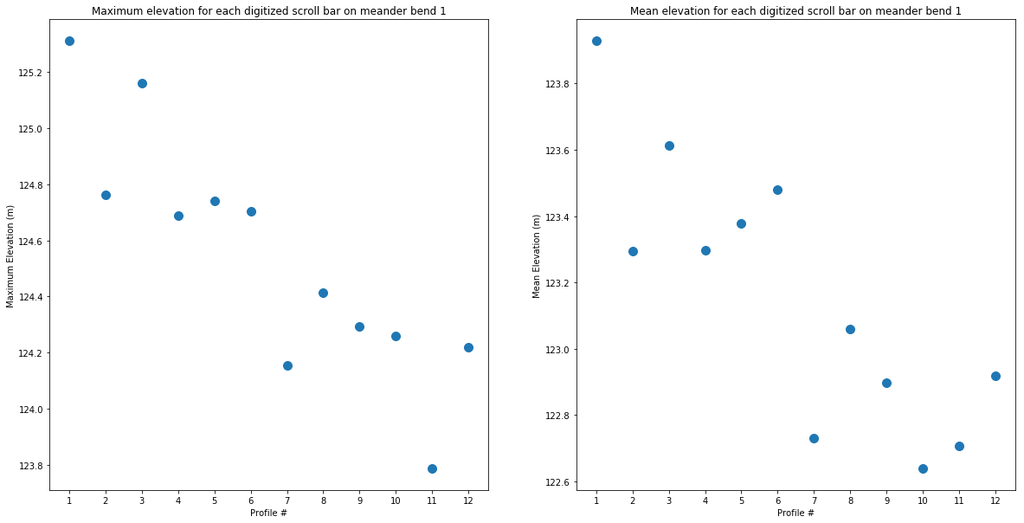

```python
fig=plt.figure(figsize=(20,10))

ax1=fig.add_subplot(1,2,1)
plt.plot(bp_stats.profile[0:12],bp_stats.maxElevation[0:12],'.', markersize = 20);
plt.xticks(np.arange(min(bp_stats.profile[0:12]), max(bp_stats.profile[0:12])+1, 1.0));
plt.xlabel('Profile #')
plt.ylabel('Maximum Elevation (m)');
plt.title('Maximum elevation for each digitized scroll bar on meander bend 1')


ax4=fig.add_subplot(1,2,2)
plt.plot(bp_stats.profile[0:12],bp_stats.meanElevation[0:12],'.', markersize = 20)
plt.xticks(np.arange(min(bp_stats.profile[0:12]), max(bp_stats.profile[0:12])+1, 1.0));
plt.xlabel('Profile #')
plt.ylabel('Mean Elevation (m)');
plt.title('Mean elevation for each digitized scroll bar on meander bend 1');
```

**Figure 15.** Crossplots of (Left) maximum and (Right) mean bar elevation for each profile on meander bend 1 (Fig. 1). Note that the profile numbers increase in the downsteam direction. Interestingly, the elevation - downstream relationship somewhat mirrors that of the channel centerline (Fig. 3)

[figure not shown]

```python
fig=plt.figure(figsize=(20,10))

ax1=fig.add_subplot(1,2,1)
plt.plot(bp_stats.profile[0:12],bp_stats.maxCurvature[0:12],'.', markersize = 20);
plt.xticks(np.arange(min(bp_stats.profile[0:12]), max(bp_stats.profile[0:12])+1, 1.0));
plt.xlabel('Profile #')
plt.ylabel('Maximum Curvature (m)');
plt.title('Maximum curvature for each digitized scroll bar on meander bend 2');

ax4=fig.add_subplot(1,2,2)
plt.plot(bp_stats.profile[0:12],bp_stats.meanCurvature[0:12],'.', markersize = 20);
plt.xticks(np.arange(min(bp_stats.profile[0:12]), max(bp_stats.profile[0:12])+1, 1.0));
plt.xlabel('Profile #')
plt.ylabel('Mean Curvature (m)');
plt.title('Mean curvature for each digitized scroll bar on meander bend 2');
```